# Ferramentas de Reclassificacao de Feições

## Ferramenta de Reclassificação de Feições

### Criando uma configuração de reclassificação

Vide Criar ajuste.

### Utilizando um ajuste de reclassificação

Ao se iniciar a ferramenta se tem acesso ao seguinte diálogo.

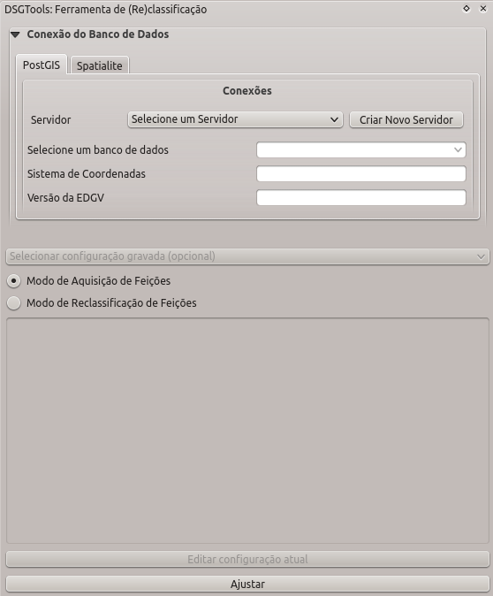

*Figura 84: Janela incial do reclassificador*

O primeiro passo é selecionar o banco de dados para se usar o reclassificador. Com isso feito é possível ter acesso ao diálogo abaixo. Clicando-se na área em destaque é possível minimizar o seletor de bancos de dados.

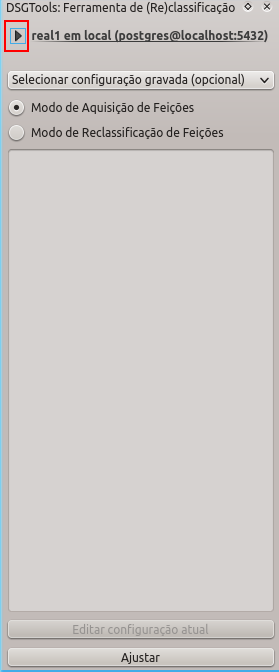

*Figura 85: Banco selecionado*

O pŕoximo passo é selecionar ou criar um ajuste de reclassificação. O Botão Ajustar permite que se crie um ajuste conforme já abordado neste manual. Sendo assim, partiremos para a seleção de um ajuste. Para tanto, basta clicar em Selecionar configuração gravada (opcional). No caso vamos selecionar o ajuste previamente criado neste manual. Com isso temos acesso ao seguinte:

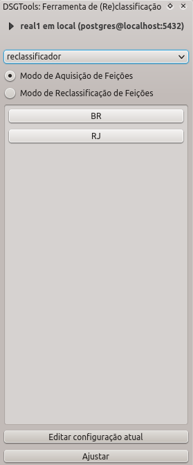

*Figura 86: Ajuste de reclassificação selecionado*

### Usando os botões criados

Vamos agora usar a configuração de reclassificação que criamos. Vamos supor que já tenhamos uma camada no QGIS de rodovias desconhecidas como se pode ver na figura 87. Agora é necessário selecionar o tipo de reclassificação:

- Modo de aquisição de feições: Permite que feições sejam adquiridas em tempo real com atributação automática de acordo com o botão selecionado.
- Modo de Reclassificação de Feições: Permite que feições previamente criadas em outras camadas sejam reclassificadas (movidas) para outra classe conforme as configurações do botão clicado.

Inicialmente vamos usar o Modo de Reclassificação de Feições.

[figure not shown]

Vamos supor que a BR-116 e a RJ-145 são as rodovias presentes na camada. Sendo assim, para reclassificar a BR-116, devemos inicialmente selecionar sua feição, como se pode ver na figura 88.

[figure not shown]

Ao se clicar no botão BR a classe correspondente da EDGV será automaticamente carregada no QGIS mostrando a feição já reclassificada como se pode ver na figura 89.

[figure not shown]

[figure not shown]

*Figura 90: Reclassificando a RJ-145*

O Modo de Aquisição de Feições inicia a ferramenta "Adicionar feição" e suprime a janela de atributação da feição pois tudo já está definido conforme o botão selecionado. Sendo assim, é possível se adiquirir feições com mais velocidade.